# 6101 Project 1

## Detroit, in the Context of Our Problem and in Time

On the other hand, cities like Detroit and San Francisco were also selected for their significance at the time. Detroit went through the largest municipal bankruptcy ever seen in the United States in 2013 (Davey & Walsh, 2013). With an estimated debt between 18 and 20 billion dollars, the city had been steadily shrinking in population since the 20th century, and parts of the city became abandoned. Due to these facts, it was expected that the median would fall over time from 2011 to 2017. This was somewhat verified by the time series plots themselves, as Detroit would consistently be at the bottom of the graphs.

```r
zillow_change <- as.data.frame(lapply(zillow_focus[2:14], diff, lag=1))
zillow_change$Date <- zillow_focus$Date[2:75]
zillow_change <- zillow_change %>% dplyr::select(Date, everything())
head(zillow_change)
```

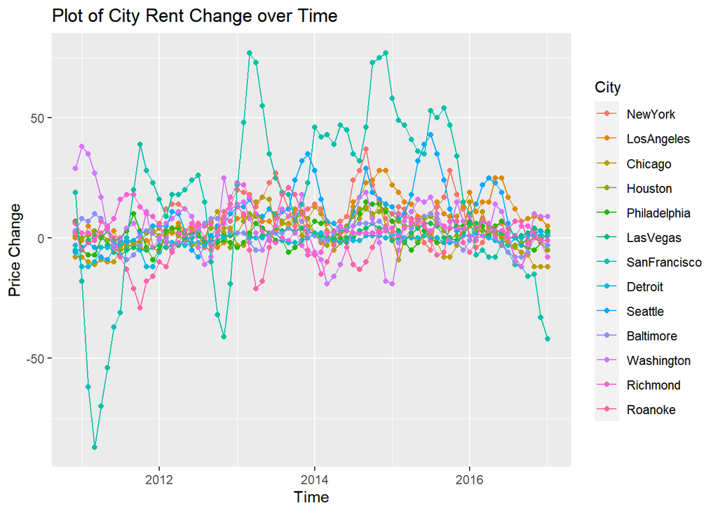

```r
zillow_cmelt <- melt(zillow_change, id = "Date")
names(zillow_cmelt)[2] <- "City"
names(zillow_cmelt)[3] <- "PriceChange"
ggplot(zillow_cmelt, aes(x=Date, y=PriceChange, group=City, color=City, na.rm=TRUE)) + geom_point() + geom_line() + labs(x="Time", y="Price Change", title="Plot of City Rent Change over Time")
```

```r
zillow_cumulative <- as.data.frame(cumsum(zillow_change[2:14]))
zillow_cumulative$Date <- zillow_focus$Date[2:75]
zillow_cumulative <- zillow_cumulative %>% dplyr::select(Date, everything())
head(zillow_cumulative)
```

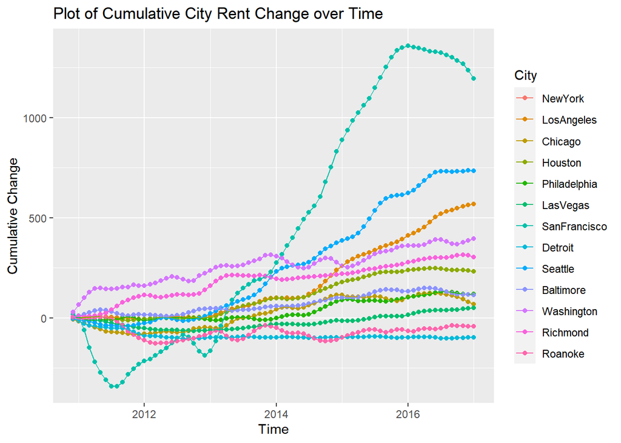

```r
zillow_cumumelt <- melt(zillow_cumulative, id = "Date")
names(zillow_cumumelt)[2] <- "City"
names(zillow_cumumelt)[3] <- "CumulativePriceChange"
ggplot(zillow_cumumelt, aes(x=Date, y=CumulativePriceChange, group=City, color=City, na.rm=TRUE)) + geom_point() + geom_line() + labs(x="Time", y="Cumulative Change", title="Plot of Cumulative City Rent Change over Time")
```